# Urban Amphibian Microbiota | Manuscript in prep

Contrasting fire salamander dermal microbiota within and urban-rural matrix

Marques, A.J.D, Gaun, N., Velo-Antón, G., Alberdi, A.

2025-06-02

# Introduction

*What are the threats toward amphibians?* Amphibians are a metaphorical canary in the coal mine when it comes to global biodiversity loss, vulnerable to multiple threats, of which many may co-occur or compound (Luedtke et al. 2023). The leading cause to amphibians’ declines is habitat loss and degradation, primarily through agriculture and urbanization, the latter of which dramatically changes habitat structures and increases the intensity of environmental stressors including changes in hydrology, temperature, and connectivity (Hamer and McDonnell 2008; Scheffers and Paszkowski 2012; Barrett and Price 2014; Yang, Zhao, and Liu 2022). Another leading cause of declines, particularly in Europe, Australia, and the Americas, has been the spread of fungal chytrid pathogens (O’Hanlon et al. 2018; Rollins-Smith and Le Sage 2021), *Batrachochytrium dendrobatidis* (Bd, Longcore, Pessier, and Nichols (1999)) and *Batrachochytrium salamandrivorans* (Bsal, Martel et al. (2013)), which have resulted in catastrophic mortality events among naive amphibian populations Fisher and Garner (2020). Efforts to model the spread of fungal pathogens have considered environmental conditions (Crawshaw et al. 2022; Thumsová et al. 2025), but the effect of land-use change and urbanization on fungal risk remains largely unknown (D. Saenz, Hall, and Kwiatkowski 2015; Bacigalupe et al. 2017).

*What has been done already?* To date, the majority of studies that have begun work characterizing amphibian microbiota have done so through targeting sequencing of 16S (Barnes et al. 2021; Santos et al. 2023). Amplicon enrichment metabarcoding utilizes existing microbial databases to identify the taxonomy of prokaryotes in a manner that is generally accessible and comparable between studies (Pruesse et al. 2007; Quast et al. 2013). Comparative studies using microbial metabarcoding identified significant variations in microbiota assemblage along urbanization gradients, but not necessarily a difference in diversity therein (Jiménez and Sommer 2017; Barnes et al. 2021; Basanta et al. 2022; Zhou et al. 2023). While suitable for repeatable taxonomic identification of prokaryote taxa, amplicon sequencing often yields a coarser taxonomic resolution and does not capture any of the functional variation which may occur within microbiome communities (Campanaro et al. 2018). To improve both the taxonomic and community assemblage resolution, we instead applied a shotgun sequencing method to generate metagenome assembled genomes (MAGs) Ranjan et al. (2016). By assembling short-read sequences into genome assemblies, we can gain improved taxonomic resolution (Ziesemer et al. 2015) and functional gene information (Bates et al. 2022; Eisenhofer, Odriozola, and Alberdi 2023). Additionally, because this methodology uses a very minimal enrichment step, the relative abundance of taxa is better preserved (Gloor et al. 2017). The compromise with this approach, however, is that host DNA is inevitably captured as well and generally comprises the majority of the sequence reads (Pereira-Marques et al. 2019). Removing host DNA generally entails mappings reads to a reference, which in the case of amphibians are often unavailable and difficult to construct owing to the often large size and complexity of amphibian genomes (Sun, López Arriaza, and Mueller 2012; Liedtke et al. 2018). Using a metagenomics approach, we aimed to collect information on how an amphibian species’ microbiome community assemblages may change in composition and function along an urbanization gradient.

*What are we hypothesizing?* To test this we sampled fire salamanders (*Salamandra salamandra*; Linnaeus 1758) from within and around the city of Porto, Portugal. Fire salamanders are a widely dispersed and abundant amphibian species typically associated with forest biomes (Wagner et al. 2020; Velo-Antón and Buckley 2015), but can also be found within a variety of urban green spaces (Lourenço et al. 2017; Iglesias-Carrasco, Martín, and Cabido 2017). Fire salamanders are affected by the spread of *Bsal* (Martel et al. 2013), with microbiome communities that may either resist or exacerbate fungal pathology (Bletz et al. 2018; Smith et al. 2018). To our knowledge Fire salamanders have thus far only ever been subject to 16S amplicon sequencing, and while characterization of the microbiome at variable life stages and habitats are available (Sanchez et al. 2017; Bletz et al. 2018; Afonso et al. 2022), misses out on the more detailed taxonomic and functional resolution that shotgun sequencing provides. Based on comparisons of other amphibian species, we would not necessarily expect a difference in community diversity does not change between communities, instead we hypothesize that compositional shifts in microbiota assemblages will be observed between urban and rural sites. Similarly, we hypothesize that differences in community assemblage will also correspond with functional variation in the microbiota of different habitats.

# Methods

### Sampling

Porto is a large urban matrix comprised of isolated urban parks of varying size and extensive forested areas comprised of both endemic and invasive tree species. Individuals were collected between mid October to early November of 2023, on nights of high humidity and when temperatures range from 14-22 ºC. This coincides with a season of peak activity, when males move above the leaf litter and present themselves as mating candidates and can be distinguished by the presence of enlarged cloacas. Using sterile gloves, individuals were collect and placed in small individualized sterile containers, ideally avoiding direct contact with salamanders, instead scooping them into the containers to reduce contact with the dermis or contamination between individuals. Salamanders were then moved to laboratory facilities the following morning to proceed with swabbing.

During swabbing a technician wearing sterile gloves (replace between samples) restrained individual salamanders by the base of the tail, using sterile paper towel to help maintain a grip. Individual were then sprayed thoroughly with distilled H2O to remove debris from the dermis. Once rinsed, the individual dermis will be swabbed ten times on the dorsal, ventral, and each side with a swab then placed in a 2 mL tube pre-filled with PBS buffer and frozen at -20ºC. After swabbing individuals are returned to their individual containers then returned to the sampled location later the same day.

### Statistics

For each sample, we calculated the proportion of sequenced bases that were filtered de to poor quality, unmapped, mapped to the host, and mapped to a MAG. The domain-adjusted mapping rate (DAMR) was used to quantify microbial genome recovery from metagenomes, calculated as the rate of read mapping to sets of microbial genomes (MAGs or other references) divided by the fraction of the community predicted to be prokaryote [Eisenhofer, Alberdi, and Woodcroft (2024). Differences in the proportion of mapped bases between habitats was determined through a Wilcox rank test (Bauer 1972). Additionally, MAG compistion was measured as the relative abundance of each MAG was determined as the number of assigned reads as a proportion of the MAG length divided by average read length to (Gloor and Reid 2016; Gloor et al. 2017), with a Tukey’s Honest Significant Difference test (TukeyHSD, Tukey (1953)) to identify significant differences in relative abundance between habitats at the phylum, class, and family taxonomic scale.

Dissimilarities between site and habitat MAGs composition were calculated in terms of richness as well as neutral, phylogenetic and functional beta diversities using Hill numbers (Hill 1973; Chao, Chiu, and Jost 2014). while considering community richness (q = 0), evenness (q > 0), and disparity between groups. Neutral Hill numbers represent species diversity without considering the degree of relatedness among MAGs; phylogenetic Hill numbers incorporate branch-length information of the phylogenetic tree of the MAGs; functional Hill numbers consider functional differences among MAGs (Hernández et al. 2024) calculated using Hilldiv2 v.2.0.2 (Alberdi and Gilbert 2019). The betadisper function in vegan v.2.6-10 (Oksanen et al. 2013) was applied to test differences in dispersion within sampling methods. PERMANOVA was performed to test for differences in microbial composition between sampling methods using the adonis2 function in vegan, with individual identity as a blocking factor to control for repeated sampling using the strata function. Once again, Wilcoxon rank sum test was used to test for differences in the variance within each group when comparing habitats and an analysis of variance (ANOVA; Chambers and Hastie (1992)) was used to compare differences in variance between sites. To visualize bacteria according to their functional features, the MAGs were ordinated based on their GIFTs through a t-SNE analysis using the Rtsne package v.0.17 (Krijthe and Van der Maaten 2015)

All statistical analyses were performed using the R software v.4.5.0 (R Core Team, 2025).

# Results

Sequencing libraries included a total of 60 swabs used to generate approximately 105M total reads (mean ± SD = 1.75 ± 2.69, median = 1.11, M reads per sample) of short-read DNA sequencing data. Quality filtering and host read removal resulted in 98.5M filtered reads (mean ± SD = 1.69 ± 2.68 , median = 0.991, Gb per sample) metagenomic data, which were assembled into 119 metagenome-assembled genomes (MAGs) that passed our minimum quality criteria (CheckM2 estimated completeness >50%, contamination <10%). With a mean 4.42 ± 1.89 Gb per sample, on average 5.8% were mapped to MAGs, while 5.3% were removed for low quality, 0.3% mapped to the host, and a substantial 88.6% were unmapped. The domain adjusted mapping rate was that an estimated 22.5 ± 20.8 % of reads were successfully mapped to MAGs.

| site | habitat | n |
| --- | --- | --- |
| Matosinhos | U | 11 |
| Tait | U | 11 |
| Carrizal | U | 8 |
| Mindelo | R | 11 |
| Vairao | R | 8 |
| Avioso | R | 11 |

## Taxonomy and Function

Majority of MAGs identified were ascribed to phyla Bacteroidota (33.61%), Pseudomonadota (30.25%), and Bacillota_A (17.65%)

(p)Bacteroidota (f)Chitinophagaceae is observed exclusively among samples from urban habitats, specifically a few individuals from Carrizal.

(p)Actinomycetota (f)Pseudonocardiaceae and (p)Bacillota (f)Erysipelotrichaceae are two Families with several identified taxa observed exclusively among samples from rural habitats. The former is specific to Vairão and the latter is among the most sparsely represented families.

Majority of the MAGs identified are new species.

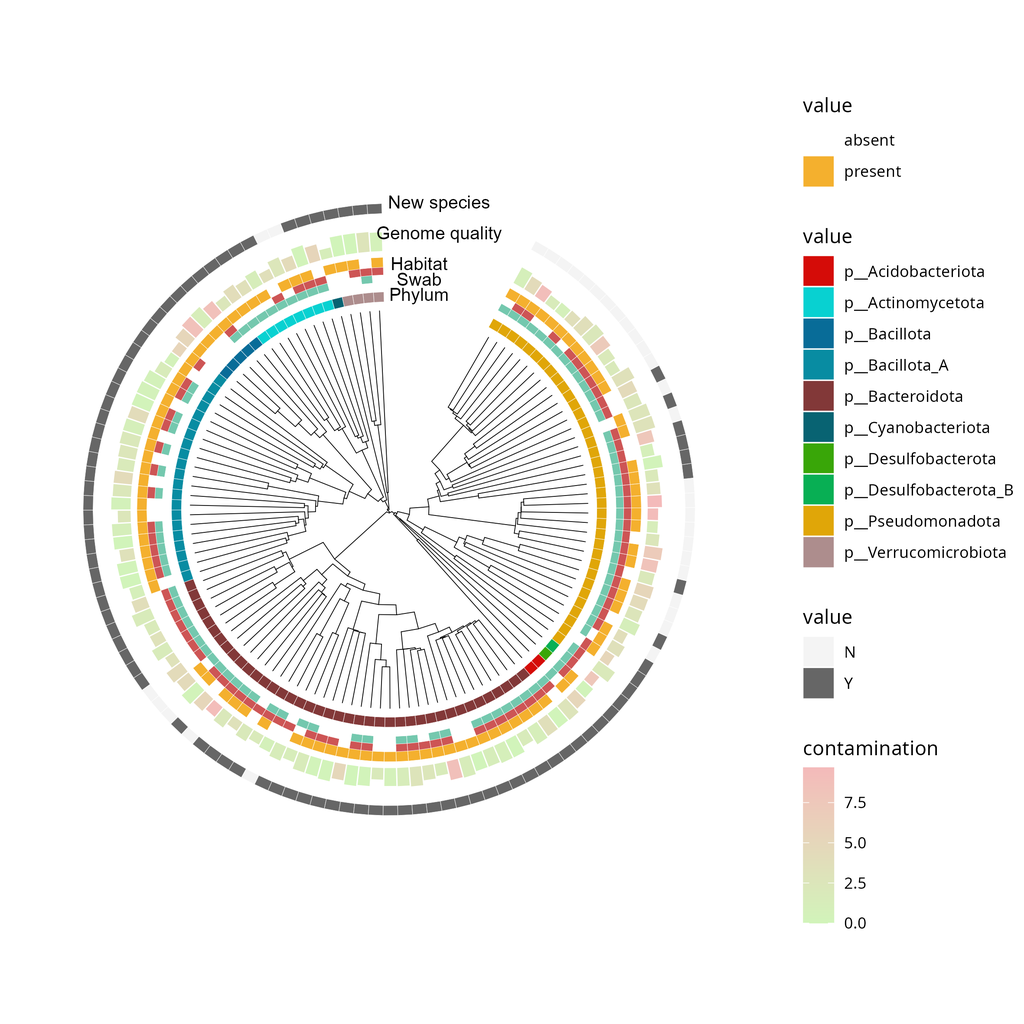

#### Notes

# Discussion

g__Acinetobacter associated with antifungal properties in other amphibians (Cevallos et al. 2022). f__Enterobacteriaceae associated with pathogenesis among other amphibians (Diaz et al. 2025).

# Acknowledgements

Thanks to Carlos Caballero-Díaz for assistance with sampling.

This publication was funded through the generous support of the Fundação para a Ciência e a Tecnologia (FCT) as part of the project “ANTHROPHIBIANS: adaptive genomic and microbiotic responses of amphibians in anthropogenic landscapes” (2021.05570.BD; https://doi.org/10.54499/2021.05570.BD).

# Bibliography

Afonso, Mariana, Laura Coelho, Fátima Jesus, Isabel Campos, Nelson Abrantes, Fernando JM Gonçalves, Sérgio Marques, and Dalila Serpa. 2022. “Effects of Pine and Eucalypt Ashes on Bacterial Isolates from the Skin Microbiome of the Fire Salamander (Salamandra Salamandra).” *Science of The Total Environment* 841: 156677.

Alberdi, Antton, and M Thomas P Gilbert. 2019. “Hilldiv: An R Package for the Integral Analysis of Diversity Based on Hill Numbers.” *BioRxiv*, 545665.

Alneberg, Johannes, Brynjar Smári Bjarnason, Ino De Bruijn, Melanie Schirmer, Joshua Quick, Umer Z Ijaz, Leo Lahti, Nicholas J Loman, Anders F Andersson, and Christopher Quince. 2014. “Binning Metagenomic Contigs by Coverage and Composition.” *Nature Methods* 11 (11): 1144–46.

Aroney, Samuel TN, Rhys JP Newell, Jakob N Nissen, Antonio Pedro Camargo, Gene W Tyson, and Ben J Woodcroft. 2025. “CoverM: Read Alignment Statistics for Metagenomics.” *arXiv Preprint arXiv:2501.11217*.

Bacigalupe, Leonardo D, Claudio Soto-Azat, Cristobal García-Vera, Ismael Barría-Oyarzo, and Enrico L Rezende. 2017. “Effects of Amphibian Phylogeny, Climate and Human Impact on the Occurrence of the Amphibian-Killing Chytrid Fungus.” *Global Change Biology* 23 (9): 3543–53.

Barnes, Elle M, Steve Kutos, Nina Naghshineh, Marissa Mesko, Qing You, and JD Lewis. 2021. “Assembly of the Amphibian Microbiome Is Influenced by the Effects of Land-Use Change on Environmental Reservoirs.” *Environmental Microbiology* 23 (8): 4595–4611.

Barrett, Kyle, and Steven J Price. 2014. “Urbanization and Stream Salamanders: A Review, Conservation Options, and Research Needs.” *Freshwater Science* 33 (3): 927–40.

Basanta, María Delia, Eria A Rebollar, Mirna G García-Castillo, Erica Bree Rosenblum, Allison Q Byrne, Jonah Piovia-Scott, and Gabriela Parra-Olea. 2022. “Genetic Variation of Batrachochytrium Dendrobatidis Is Linked to Skin Bacterial Diversity in the Pacific Treefrog Hyliola Regilla (Hypochondriaca).” *Environmental Microbiology* 24 (1): 494–506.

Bates, Kieran A, Ulf Sommer, Kevin P Hopkins, Jennifer MG Shelton, Claudia Wierzbicki, Christopher Sergeant, Benjamin Tapley, et al. 2022. “Microbiome Function Predicts Amphibian Chytridiomycosis Disease Dynamics.” *Microbiome* 10 (1): 44.

Bauer, David F. 1972. “Constructing Confidence Sets Using Rank Statistics.” *Journal of the American Statistical Association* 67 (339): 687–90.

Bletz, Molly C, Moira Kelly, Joana Sabino-Pinto, Emma Bales, Sarah Van Praet, Wim Bert, Filip Boyen, et al. 2018. “Disruption of Skin Microbiota Contributes to Salamander Disease.” *Proceedings of the Royal Society B* 285 (1885): 20180758.

Bletz, Molly C, Andrew H Loudon, Matthew H Becker, Sara C Bell, Douglas C Woodhams, Kevin PC Minbiole, and Reid N Harris. 2013. “Mitigating Amphibian Chytridiomycosis with Bioaugmentation: Characteristics of Effective Probiotics and Strategies for Their Selection and Use.” *Ecology Letters* 16 (6): 807–20.

Bowers, Robert M, Nikos C Kyrpides, Ramunas Stepanauskas, Miranda Harmon-Smith, Devin Doud, TBK Reddy, Frederik Schulz, et al. 2017. “Minimum Information about a Single Amplified Genome (MISAG) and a Metagenome-Assembled Genome (MIMAG) of Bacteria and Archaea.” *Nature Biotechnology* 35 (8): 725–31.

Brown, Thomas, Ketan Mishra, Ahmed Elewa, Svetlana Iarovenko, Elaiyaraja Subramanian, Alberto Joven Araus, Andreas Petzold, et al. 2025. “Chromosome-Scale Genome Assembly Reveals How Repeat Elements Shape Non-Coding RNA Landscapes Active During Newt Limb Regeneration.” *Cell Genomics* 5 (2).

Cachada, A, P Pato, T Rocha-Santos, E Ferreira da Silva, and AC Duarte. 2012. “Levels, Sources and Potential Human Health Risks of Organic Pollutants in Urban Soils.” *Science of the Total Environment* 430: 184–92.

Campanaro, Stefano, Laura Treu, Panagiotis G Kougias, Xinyu Zhu, and Irini Angelidaki. 2018. “Taxonomy of Anaerobic Digestion Microbiome Reveals Biases Associated with the Applied High Throughput Sequencing Strategies.” *Scientific Reports* 8 (1): 1926.

Cantarel, Brandi L, Pedro M Coutinho, Corinne Rancurel, Thomas Bernard, Vincent Lombard, and Bernard Henrissat. 2009. “The Carbohydrate-Active EnZymes Database (CAZy): An Expert Resource for Glycogenomics.” *Nucleic Acids Research* 37 (suppl_1): D233–38.

Carøe, Christian, Shyam Gopalakrishnan, Lasse Vinner, Sarah ST Mak, Mikkel Holger S Sinding, José A Samaniego, Nathan Wales, Thomas Sicheritz-Pontén, and M Thomas P Gilbert. 2018. “Single-Tube Library Preparation for Degraded DNA.” *Methods in Ecology and Evolution* 9 (2): 410–19.

Cevallos, MA, MD Basanta, E Bello-López, AS Escobedo-Muñoz, FM González-Serrano, A Nemec, YJ Romero-Contreras, M Serrano, and EA Rebollar. 2022. “Genomic Characterization of Antifungal Acinetobacter Bacteria Isolated from the Skin of the Frogs Agalychnis Callidryas and Craugastor Fitzingeri.” *FEMS Microbiology Ecology* 98 (12): fiac126.

Chambers, J. M., and T. J. Hastie. 1992. *Statistical Models in S*. Wadsworth & Brooks/Cole.

Chao, Anne, Chun-Huo Chiu, and Lou Jost. 2014. “Unifying Species Diversity, Phylogenetic Diversity, Functional Diversity, and Related Similarity and Differentiation Measures Through Hill Numbers.” *Annual Review of Ecology, Evolution, and Systematics* 45 (1): 297–324.

Chaumeil, Pierre-Alain, Aaron J Mussig, Philip Hugenholtz, and Donovan H Parks. 2022. “GTDB-Tk V2: Memory Friendly Classification with the Genome Taxonomy Database.” *Bioinformatics* 38 (23): 5315–16.

Chen, Shifu, Yanqing Zhou, Yaru Chen, and Jia Gu. 2018. “Fastp: An Ultra-Fast All-in-One FASTQ Preprocessor.” *Bioinformatics* 34 (17): i884–90.

Clevenot, Laura, Catherine Carré, and Pierre Pech. 2018. “A Review of the Factors That Determine Whether Stormwater Ponds Are Ecological Traps and/or High-Quality Breeding Sites for Amphibians.” *Frontiers in Ecology and Evolution* 6: 40.

Crawshaw, Lauren, Tore Buchanan, Leonard Shirose, Amanda Palahnuk, Hugh Y Cai, Amanda M Bennett, Claire M Jardine, and Christina M Davy. 2022. “Widespread Occurrence of Batrachochytrium Dendrobatidis in Ontario, Canada, and Predicted Habitat Suitability for the Emerging Batrachochytrium Salamandrivorans.” *Ecology and Evolution* 12 (4): e8798.

Danecek, Petr, James K Bonfield, Jennifer Liddle, John Marshall, Valeriu Ohan, Martin O Pollard, Andrew Whitwham, et al. 2021. “Twelve Years of SAMtools and BCFtools.” *Gigascience* 10 (2): giab008.

Diaz, Osvaldo Lopez, Antonio Buendia, Joaquín Sánchez, Guiehdani Villalobos, Nora Rojas-Serrania, José Antonio Ocampo Cervantes, Fernando Uranga-Muñoz, Fernando Martinez-Hernandez, Emilio Rendón-Franco, and Claudia Irais Muñoz-García. 2025. “Identification of Enterobacteriaceae Causing Septicemia in the Axolotl Ambystoma Mexicanum.” *Antonie van Leeuwenhoek* 118 (3): 56.

Duong, Trang TT, and Byeong-Kyu Lee. 2011. “Determining Contamination Level of Heavy Metals in Road Dust from Busy Traffic Areas with Different Characteristics.” *Journal of Environmental Management* 92 (3): 554–62.

Eisenhofer, Raphael, Antton Alberdi, and Ben J Woodcroft. 2024. “Quantifying Microbial DNA in Metagenomes Improves Microbial Trait Estimation.” *ISME Communications* 4 (1): ycae111.

Eisenhofer, Raphael, Iñaki Odriozola, and Antton Alberdi. 2023. “Impact of Microbial Genome Completeness on Metagenomic Functional Inference.” *ISME Communications* 3 (1): 12.

Finn, Robert D, Penelope Coggill, Ruth Y Eberhardt, Sean R Eddy, Jaina Mistry, Alex L Mitchell, Simon C Potter, et al. 2016. “The Pfam Protein Families Database: Towards a More Sustainable Future.” *Nucleic Acids Research* 44 (D1): D279–85.

Fisher, Matthew C, and Trenton WJ Garner. 2020. “Chytrid Fungi and Global Amphibian Declines.” *Nature Reviews Microbiology* 18 (6): 332–43.

Gentili, Rodolfo, Lara A Quaglini, Gabriele Galasso, Chiara Montagnani, Sarah Caronni, Elisa Cardarelli, and Sandra Citterio. 2024. “Urban Refugia Sheltering Biodiversity Across World Cities.” *Urban Ecosystems* 27 (1): 219–30.

Gloor, Gregory B, Jean M Macklaim, Vera Pawlowsky-Glahn, and Juan J Egozcue. 2017. “Microbiome Datasets Are Compositional: And This Is Not Optional.” *Frontiers in Microbiology* 8: 2224.

Gloor, Gregory B, and Gregor Reid. 2016. “Compositional Analysis: A Valid Approach to Analyze Microbiome High-Throughput Sequencing Data.” *Canadian Journal of Microbiology* 62 (8): 692–703.

González-Serrano, Francisco, Yordan J Romero-Contreras, Alberto H Orta, M Delia Basanta, Hugo Morales, Gabriela Sandoval García, Elena Bello-López, et al. 2025. “Amphibian Skin Bacteria Contain a Wide Repertoire of Genes Linked to Their Antifungal Capacities.” *World Journal of Microbiology and Biotechnology* 41 (3): 78.

Gurevich, Alexey, Vladislav Saveliev, Nikolay Vyahhi, and Glenn Tesler. 2013. “QUAST: Quality Assessment Tool for Genome Assemblies.” *Bioinformatics* 29 (8): 1072–75.

Hamer, Andrew J, and Mark J McDonnell. 2008. “Amphibian Ecology and Conservation in the Urbanising World: A Review.” *Biological Conservation* 141 (10): 2432–49.

Hernández, Mauricio, Jorge Langa, Ostaizka Aizpurua, Yendi E Navarro-Noya, and Antton Alberdi. 2024. “Contrasting Recovery of Metagenome-Assembled Genomes and Derived Microbial Communities from Lizard Fecal and Cloacal Samples.”

Hill, Mark O. 1973. “Diversity and Evenness: A Unifying Notation and Its Consequences.” *Ecology* 54 (2): 427–32.

Hu, Yinhong, Xiaolin Dou, Juanyong Li, and Feng Li. 2018. “Impervious Surfaces Alter Soil Bacterial Communities in Urban Areas: A Case Study in Beijing, China.” *Frontiers in Microbiology* 9: 226.

Iglesias-Carrasco, Maider, José Martín, and Carlos Cabido. 2017. “Urban Habitats Can Affect Body Size and Body Condition but Not Immune Response in Amphibians.” *Urban Ecosystems* 20: 1331–38.

Jani, Andrea J, Jessie Bushell, Cédric G Arisdakessian, Mahdi Belcaid, Daniel M Boiano, Cathy Brown, and Roland A Knapp. 2021. “The Amphibian Microbiome Exhibits Poor Resilience Following Pathogen-Induced Disturbance.” *The ISME Journal* 15 (6): 1628–40.

Jiménez, Randall R, and Simone Sommer. 2017. “The Amphibian Microbiome: Natural Range of Variation, Pathogenic Dysbiosis, and Role in Conservation.” *Biodiversity and Conservation* 26: 763–86.

Kanehisa, Minoru, Miho Furumichi, Mao Tanabe, Yoko Sato, and Kanae Morishima. 2017. “KEGG: New Perspectives on Genomes, Pathways, Diseases and Drugs.” *Nucleic Acids Research* 45 (D1): D353–61.

Kang, Dongwan D, Feng Li, Edward Kirton, Ashleigh Thomas, Rob Egan, Hong An, and Zhong Wang. 2019. “MetaBAT 2: An Adaptive Binning Algorithm for Robust and Efficient Genome Reconstruction from Metagenome Assemblies.” *PeerJ* 7: e7359.

Krijthe, Jesse H, and L Van der Maaten. 2015. “Rtsne: T-Distributed Stochastic Neighbor Embedding Using Barnes-Hut Implementation. R Package Version 0.13.” *Computer Software*.

Kueneman, Jordan G, Molly C Bletz, Matthew Becker, Brian Gratwicke, Orlando A Garcés, Andreas Hertz, Whitney M Holden, et al. 2022. “Effects of Captivity and Rewilding on Amphibian Skin Microbiomes.” *Biological Conservation* 271: 109576.

Langmead, Ben, and Steven L Salzberg. 2012. “Fast Gapped-Read Alignment with Bowtie 2.” *Nature Methods* 9 (4): 357–59.

Le Sage, Emily H, Brandon C LaBumbard, Laura K Reinert, Brian T Miller, Corinne L Richards-Zawacki, Doug C Woodhams, and Louise A Rollins-Smith. 2021. “Preparatory Immunity: Seasonality of Mucosal Skin Defences and Batrachochytrium Infections in Southern Leopard Frogs.” *Journal of Animal Ecology* 90 (2): 542–54.

Leonard, Aoife, Javier Abalos, Titus Adhola, Windsor Aguirre, Ostaizka Aizpurua, Shahzad Ali, Franco Andreone, et al. 2024. “A Global Initiative for Ecological and Evolutionary Hologenomics.” *Trends in Ecology & Evolution*.

Libro, Pietro, Andrea Chiocchio, Erika De Rysky, Jessica Di Martino, Roberta Bisconti, Tiziana Castrignanò, and Daniele Canestrelli. 2023. “De Novo Transcriptome Assembly and Annotation for Gene Discovery in Salamandra Salamandra at the Larval Stage.” *Scientific Data* 10 (1): 330.

Liedtke, H Christoph, David J Gower, Mark Wilkinson, and Ivan Gomez-Mestre. 2018. “Macroevolutionary Shift in the Size of Amphibian Genomes and the Role of Life History and Climate.” *Nature Ecology & Evolution* 2 (11): 1792–99.

Lips, Karen R. 2016. “Overview of Chytrid Emergence and Impacts on Amphibians.” *Philosophical Transactions of the Royal Society B: Biological Sciences* 371 (1709): 20150465.

Longcore, Joyce E, Allan P Pessier, and Donald K Nichols. 1999. “Batrachochytrium Dendrobatidis Gen. Et Sp. Nov., a Chytrid Pathogenic to Amphibians.” *Mycologia* 91 (2): 219–27.

Lourenço, André, David Álvarez, Ian J Wang, and Guillermo Velo-Antón. 2017. “Trapped Within the City: Integrating Demography, Time Since Isolation and Population-Specific Traits to Assess the Genetic Effects of Urbanization.” *Molecular Ecology* 26 (6): 1498–1514.

Luedtke, Jennifer A, Janice Chanson, Kelsey Neam, Louise Hobin, Adriano O Maciel, Alessandro Catenazzi, Amaël Borzée, et al. 2023. “Ongoing Declines for the World’s Amphibians in the Face of Emerging Threats.” *Nature* 622 (7982): 308–14.

Martel, An, Annemarieke Spitzen-van der Sluijs, Mark Blooi, Wim Bert, Richard Ducatelle, Matthew C Fisher, Antonius Woeltjes, et al. 2013. “Batrachochytrium Salamandrivorans Sp. Nov. Causes Lethal Chytridiomycosis in Amphibians.” *Proceedings of the National Academy of Sciences* 110 (38): 15325–29.

McGarvey, Peter B, Andrew Nightingale, Jie Luo, Hongzhan Huang, Maria J Martin, Cathy Wu, and UniProt Consortium. 2019. “UniProt Genomic Mapping for Deciphering Functional Effects of Missense Variants.” *Human Mutation* 40 (6): 694–705.

McLellan, Sandra L, Jenny C Fisher, and Ryan J Newton. 2015. “The Microbiome of Urban Waters.” *International Microbiology: The Official Journal of the Spanish Society for Microbiology* 18 (3): 141.

Muletz, Carly R, Jillian M Myers, Rickie J Domangue, James B Herrick, and Reid N Harris. 2012. “Soil Bioaugmentation with Amphibian Cutaneous Bacteria Protects Amphibian Hosts from Infection by Batrachochytrium Dendrobatidis.” *Biological Conservation* 152: 119–26.

Muletz-Wolz, Carly R, Jose G Almario, Samuel E Barnett, Graziella V DiRenzo, An Martel, Frank Pasmans, Kelly R Zamudio, Luís Felipe Toledo, and Karen R Lips. 2017. “Inhibition of Fungal Pathogens Across Genotypes and Temperatures by Amphibian Skin Bacteria.” *Frontiers in Microbiology* 8: 1551.

Murray, Dáithí C, Megan L Coghlan, and Michael Bunce. 2015. “From Benchtop to Desktop: Important Considerations When Designing Amplicon Sequencing Workflows.” *PloS One* 10 (4): e0124671.

O’Hanlon, Simon J, Adrien Rieux, Rhys A Farrer, Gonçalo M Rosa, Bruce Waldman, Arnaud Bataille, Tiffany A Kosch, et al. 2018. “Recent Asian Origin of Chytrid Fungi Causing Global Amphibian Declines.” *Science* 360 (6389): 621–27.

Oksanen, Jari, F Guillaume Blanchet, Roeland Kindt, Pierre Legendre, Peter R Minchin, RB O’hara, Gavin L Simpson, et al. 2013. “Package ‘Vegan’.” *Community Ecology Package, Version* 2 (9): 1–295.

Olm, Matthew R, Christopher T Brown, Brandon Brooks, and Jillian F Banfield. 2017. “dRep: A Tool for Fast and Accurate Genomic Comparisons That Enables Improved Genome Recovery from Metagenomes Through de-Replication.” *The ISME Journal* 11 (12): 2864–68.

Parks, Donovan H, Maria Chuvochina, Christian Rinke, Aaron J Mussig, Pierre-Alain Chaumeil, and Philip Hugenholtz. 2022. “GTDB: An Ongoing Census of Bacterial and Archaeal Diversity Through a Phylogenetically Consistent, Rank Normalized and Complete Genome-Based Taxonomy.” *Nucleic Acids Research* 50 (D1): D785–94.

Pereira-Marques, Joana, Anne Hout, Rui M Ferreira, Michiel Weber, Ines Pinto-Ribeiro, Leen-Jan Van Doorn, Cornelis Willem Knetsch, and Ceu Figueiredo. 2019. “Impact of Host DNA and Sequencing Depth on the Taxonomic Resolution of Whole Metagenome Sequencing for Microbiome Analysis.” *Frontiers in Microbiology* 10: 1277.

Pietroni, Carlotta, Nanna Gaun, Aoife Leonard, Jonas Lauritsen, Garazi Martin-Bideguren, Iñaki Odriozola, Ostaizka Aizpurua, Antton Alberdi, and Raphael Eisenhofer. 2025. “Hologenomic Data Generation and Analysis in Wild Vertebrates.” *Methods in Ecology and Evolution* 16 (1): 97–107.

Pruesse, Elmar, Christian Quast, Katrin Knittel, Bernhard M Fuchs, Wolfgang Ludwig, Jörg Peplies, and Frank Oliver Glöckner. 2007. “SILVA: A Comprehensive Online Resource for Quality Checked and Aligned Ribosomal RNA Sequence Data Compatible with ARB.” *Nucleic Acids Research* 35 (21): 7188–96.

Quast, Christian, Elmar Pruesse, Pelin Yilmaz, Jan Gerken, Timmy Schweer, Pablo Yarza, Jörg Peplies, and Frank Oliver Glöckner. 2013. “The SILVA Ribosomal RNA Gene Database Project: Improved Data Processing and Web-Based Tools.” *Nucleic Acids Research* 41 (D1): D590–96.

Ranjan, Ravi, Asha Rani, Ahmed Metwally, Halvor S McGee, and David L Perkins. 2016. “Analysis of the Microbiome: Advantages of Whole Genome Shotgun Versus 16S Amplicon Sequencing.” *Biochemical and Biophysical Research Communications* 469 (4): 967–77.

Rawlings, Neil D, and Alan J Barrett. 1999. “MEROPS: The Peptidase Database.” *Nucleic Acids Research* 27 (1): 325–31.

Rebollar, Eria A, Emanuel Martínez-Ugalde, and Alberto H Orta. 2020. “The Amphibian Skin Microbiome and Its Protective Role Against Chytridiomycosis.” *Herpetologica* 76 (2): 167–77.

Robak, Matthew J, Veronica Saenz, Esmee de Cortie, and Corinne L Richards-Zawacki. 2023. “Effects of Temperature on the Interaction Between Amphibian Skin Bacteria and Batrachochytrium Dendrobatidis.” *Frontiers in Microbiology* 14: 1253482.

Rollins-Smith, Louise A, and Emily H Le Sage. 2021. “Batrachochytrium Fungi: Stealth Invaders in Amphibian Skin.” *Current Opinion in Microbiology* 61: 124–32.

Saenz, Daniel, Taylor L Hall, and Matthew A Kwiatkowski. 2015. “Effects of Urbanization on the Occurrence of Batrachochytrium Dendrobatidis: Do Urban Environments Provide Refuge from the Amphibian Chytrid Fungus?” *Urban Ecosystems* 18: 333–40.

Saenz, Veronica, Allison Q Byrne, Michel EB Ohmer, Talisin T Hammond, Laura A Brannelly, Karie A Altman, Miranda Kosowsky, Caitlin L Nordheim, Erica Bree Rosenblum, and Corinne L Richards-Zawacki. 2025. “Landscape-Scale Drivers of Spatial Dynamics and Genetic Diversity in an Emerging Wildlife Pathogen.” *Oecologia* 207 (1): 1–16.

Sanchez, Eugenia, Molly C Bletz, Laura Duntsch, Sabin Bhuju, Robert Geffers, Michael Jarek, Anja B Dohrmann, Christoph C Tebbe, Sebastian Steinfartz, and Miguel Vences. 2017. “Cutaneous Bacterial Communities of a Poisonous Salamander: A Perspective from Life Stages, Body Parts and Environmental Conditions.” *Microbial Ecology* 73 (2): 455–65.

Santos, Bárbara, Filipa MS Martins, Joana Sabino-Pinto, Fulvio Licata, and Angelica Crottini. 2023. “Skin and Gut Microbiomes of Tadpoles Vary Differently with Host and Water Environment: A Short-Term Experiment Using 16S Metabarcoding.” *Scientific Reports* 13 (1): 16321.

Scheffers, Brett R, and Cynthia A Paszkowski. 2012. “The Effects of Urbanization on North American Amphibian Species: Identifying New Directions for Urban Conservation.” *Urban Ecosystems* 15: 133–47.

Schmidt, Chloé, and Colin J Garroway. 2021. “The Population Genetics of Urban and Rural Amphibians in North America.” *Molecular Ecology* 30 (16): 3918–29.

Shaffer, Michael, Mikayla A Borton, Bridget B McGivern, Ahmed A Zayed, Sabina Leanti La Rosa, Lindsey M Solden, Pengfei Liu, et al. 2020. “DRAM for Distilling Microbial Metabolism to Automate the Curation of Microbiome Function.” *Nucleic Acids Research* 48 (16): 8883–8900.

Skerratt, Lee Francis, Lee Berger, Richard Speare, Scott Cashins, Keith Raymond McDonald, Andrea Dawn Phillott, Harry Bryan Hines, and Nicole Kenyon. 2007. “Spread of Chytridiomycosis Has Caused the Rapid Global Decline and Extinction of Frogs.” *EcoHealth* 4 (2): 125–34.

Smith, Hannah Keely, Frank Pasmans, Maarten Dhaenens, Dieter Deforce, Dries Bonte, Kris Verheyen, Luc Lens, and An Martel. 2018. “Skin Mucosome Activity as an Indicator of Batrachochytrium Salamandrivorans Susceptibility in Salamanders.” *PLoS One* 13 (7): e0199295.

Sun, Cheng, José R López Arriaza, and Rachel Lockridge Mueller. 2012. “Slow DNA Loss in the Gigantic Genomes of Salamanders.” *Genome Biology and Evolution* 4 (12): 1340–48.

Thumsová, Barbora, Alejandra Zarzo-Arias, José V Roces-Díaz, Albert Martínez-Silvestre, Jason R Rohr, and Jaime Bosch. 2025. “Ecological Niche Models Based on Occurrence Records of the Amphibian Chytrid Fungus Overestimate Lethal Chytridiomycosis Risk.” *Journal of Applied Ecology* 62 (4): 995–1006.

Tukey, John Wilder. 1953. “The Problem of Multiple Comparisons.” *Multiple Comparisons*.

Uritskiy, Gherman V, Jocelyne DiRuggiero, and James Taylor. 2018. “MetaWRAP—a Flexible Pipeline for Genome-Resolved Metagenomic Data Analysis.” *Microbiome* 6: 1–13.

Van Rooij, Pascale, An Martel, Freddy Haesebrouck, and Frank Pasmans. 2015. “Amphibian Chytridiomycosis: A Review with Focus on Fungus-Host Interactions.” *Veterinary Research* 46: 1–22.

Velo-Antón, Guillermo, and David Buckley. 2015. “Salamandra Común–Salamandra Salamandra (Linnaeus, 1758).”

Wagner, Norman, Wiebke Harms, Florian Hildebrandt, Alexandra Martens, Suan Li Ong, Katja Wallrich, Stefan Lötters, and Michael Veith. 2020. “Do Habitat Preferences of European Fire Salamander (Salamandra Salamandra) Larvae Differ Among Landscapes? A Case Study from Western Germany.” *Salamandra* 56 (3).

Weinstock, George M. 2012. “Genomic Approaches to Studying the Human Microbiota.” *Nature* 489 (7415): 250–56.

Wu, Yu-Wei, Blake A Simmons, and Steven W Singer. 2016. “MaxBin 2.0: An Automated Binning Algorithm to Recover Genomes from Multiple Metagenomic Datasets.” *Bioinformatics* 32 (4): 605–7.

Yang, Lu, Shuqing Zhao, and Shuguang Liu. 2022. “A Global Analysis of Urbanization Effects on Amphibian Richness: Patterns and Drivers.” *Global Environmental Change* 73: 102476.

Zhang, Peng, Theodore J Papenfuss, Marvalee H Wake, Lianghu Qu, and David B Wake. 2008. “Phylogeny and Biogeography of the Family Salamandridae (Amphibia: Caudata) Inferred from Complete Mitochondrial Genomes.” *Molecular Phylogenetics and Evolution* 49 (2): 586–97.

Zhou, Jin, Ziyan Liao, Zhidong Liu, Xuecheng Guo, Wenyan Zhang, and Youhua Chen. 2023. “Urbanization Increases Stochasticity and Reduces the Ecological Stability of Microbial Communities in Amphibian Hosts.” *Frontiers in Microbiology* 13: 1108662.

Ziesemer, Kirsten A, Allison E Mann, Krithivasan Sankaranarayanan, Hannes Schroeder, Andrew T Ozga, Bernd W Brandt, Egija Zaura, et al. 2015. “Intrinsic Challenges in Ancient Microbiome Reconstruction Using 16S rRNA Gene Amplification.” *Scientific Reports* 5 (1): 16498.